# 2020-03-23 Week 3 Notebook

Jon Page

# Introduction

This notebook is to track my work in the week commencing 23/03/20.

Following Zoom with Martin and Gab, the below are my targets for this week:

1. Take FLUXNET data from one site and test it OOS
- Model NEE as function of precip, VPD and Temp
- Run the SAM approach over a few years and then see how the model works for the following years
- I could investigate whether the 3-6 model works for it at all.
2. Sort out working from home
3. Read and produce a “BIG” question along with some hypotheses to test within this question’s framework

# BIG QUESTION:

### To what extent does the productivity of grasslands depend on antecedent climate and how is this influenced by eCO<sub>2</sub>?

1. **Which antecedent effects are most important?**

Precipitation will be seen to have the longest historical period due to the extended time periods over which soil moisture varies. However, it will be seen that temperature and vapour pressure deficit will also have an impact on a more recent timescale.

2. **What timescales do lags operate over?**

The timescale of lags is very dependent on the climate variable being examined. However, overall, it will be important to consider the previous ~5 years when attempting to explain grassland productivity. Since plants exposed to eCO<sub>2</sub> have a greater capacity for production, I expect the influence of antecedent effects to become greater as plants are more able to take advantage of any increase in resources.

3. **How does the role of antecedent effects change based on the prevailing climate at a site?**

The importance of lagged climatic variables will vary based on the ecosystem but across grasslands, antecedent precipitation will consistently be the most influential historical influence. This is due to the majority of grasslands being water-limited. This will not change significantly under eCO<sub>2</sub> as water savings in grassland are offset by the greater climatic variability.

4. **How do extreme events interact with the role of lags in grasslands ecosystems?**

Extreme events will produce longer-lasting impacts that propogate through the productivity response over wider timespans than the average years. This however will be mitigated under climate change as enhanced WUE and higher productivity provide a cushioning effect.

# netCDF Files

First up is accessing the netCDF files saved at the below link and finding which ones are from grassland sites

/srv/ccrc/data04/z3509830/Fluxnet_data/All_flux_sites_processed_PLUMBER2/Post-processed_PLUMBER2_outputs

https://fluxnet.fluxdata.org/sites/site-list-and-pages/ has a list of the sites by IGBP classification for the FLUXNET 2015 files.

https://fluxnet.fluxdata.org/data/la-thuile-dataset/ This page has the list for the La Thuile sites. No La Thuile datasets for grassland sites are over 10 years of length (or more than about 5).

Similarly, http://www.ozflux.org.au/monitoringsites/ shows that the 2 sites from OzFlux that had longer time series of data were not grasslands.

The below commands were used to copy the Met and Flux files from the storm servers to my PC:

```bash
scp z5293113@maelstrom.ccrc.unsw.edu.au:/srv/ccrc/data04/z3509830/Fluxnet_data/All_flux_sites_processed_PLUMBER2/Post-processed_PLUMBER2_outputs/Nc_files/Flux/US-Wkg_2005-2014_FLUXNET2015_Flux.nc .

scp z5293113@maelstrom.ccrc.unsw.edu.au:/srv/ccrc/data04/z3509830/Fluxnet_data/All_flux_sites_processed_PLUMBER2/Post-processed_PLUMBER2_outputs/Nc_files/Met/US-Wkg_2005-2014_FLUXNET2015_Met.nc .
```

We now have to extract the data and turn it into the format we want:

```r
name = "US-Wkg_2005-2014_FLUXNET2015_"

Met = nc_open(paste0(name,"Met.nc"))
Flux = nc_open(paste0(name,"Flux.nc"))

time = ncvar_get(Met,"time")
Tair = ncvar_get(Met,"Tair")
Precip = ncvar_get(Met,"Precip")
VPD = ncvar_get(Met,"VPD")
NEE = ncvar_get(Flux,"NEE")

ncatt_get(Met, "time")
```

```
## $units
## [1] "seconds since 2005-01-01 00:00:00"
##
## $calendar
## [1] "standard"
```

```r
time_from = substr(ncatt_get(Met, "time")$units, 15, 33)
time <- as.POSIXct(time, origin=time_from)

nc_close(Met)
nc_close(Flux)

# Define unit conversions
SEC_TO_30MIN = 1800
KEL_TO_CEL = -273.15

# Create data frame with the units converted
# Precip is now in mm
# Tair is now in Celsius
df <- data.frame(time, NEE, Tair+KEL_TO_CEL,Precip*SEC_TO_30MIN,VPD)
colnames(df)<- c("time","NEE","Tair","Precip","VPD")


df_day <- df %>%
      mutate(day=as.Date(time, format="%Y-%m-%d")) %>%
      group_by(day) %>%               # group by the day column
      summarise(NEE=sum(NEE),Tair=mean(Tair),Precip=sum(Precip),VPD=mean(VPD))

df_month <- df_day %>%
      mutate(month=format(as.Date(df_day$day),"%Y-%m")) %>%
      group_by(month) %>%               # group by the day column
      summarise(NEE=sum(NEE),Tair=mean(Tair),Precip=sum(Precip),VPD=mean(VPD))

# Create our Precip input matrix
Precip = data.frame(matrix(df_month$Precip,ncol = 12, byrow = TRUE))
colnames(Precip) <- c("ppt1","ppt2","ppt3","ppt4","ppt5","ppt6","ppt7","ppt8","ppt9","ppt10","ppt11","ppt12")

# Create the NEE input matrix

df_day$Year = format(df_day$day,"%Y")
NEE = aggregate(df_day['NEE'],by=df_day['Year'],sum)
```

Important differences from the code replicating Ogle et al:

1. I will NOT consider the precipitation events of the current year - Ogle et al showed that these were insignificant for their site and they are also considered under the monthly weights
2. I will NOT set the weights of Oct/Nov/Dec of the current year to zero - since we are using flux-derived NEE rather than harvested biomass, this is no longer relevant.
3. I WILL consider weights for monthly mean temp and VPD.
4. Assuming that all sites have the same length of Precip data and NEE data, I have had to amend the code which previously assumed that we always had Nlag prior years of Precip for the first year of NPP data

```r
source("SAMFunction.R")
timeblock = SpringBlock(3)
```

```
##      [,1] [,2] [,3] [,4] [,5] [,6] [,7] [,8] [,9] [,10] [,11] [,12]
## [1,]    1    1    1    2    2    2    1    1    1     1     1     1
## [2,]    3    3    3    4    4    4    3    3    3     3     3     3
## [3,]    5    5    5    6    6    6    5    5    5     5     5     5
```

```r
Nlag = timeblock$Nlag
block = timeblock$block
NEE = NEE[-(1:Nlag),]
# For the timeblock created, run the model
SAM(Precip,NEE,Nlag,block,prior=FALSE)
```

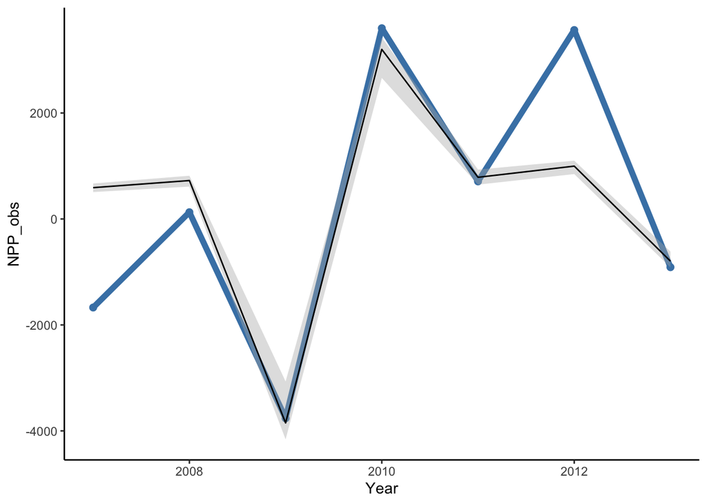

```r
load("SAM_posterior_3_6_20200325_152051.Rdata")
library(ggplot2)
library(gridExtra) # Source gridExtra for better plots
NPPobs = data.frame(Year=1:nrow(NEE)+2006,
                    NPP_obs = NEE[,2])
NPPmod = data.frame(Year=1:length(SAM_posterior_3_6_20200325_152051$NPPmod$mean)+2006,
                    NPP_mod = SAM_posterior_3_6_20200325_152051$NPPmod$mean,
                    NPP_modmin = SAM_posterior_3_6_20200325_152051$NPPmod$min,
                    NPP_modmax = SAM_posterior_3_6_20200325_152051$NPPmod$max)
plot3 <- ggplot(NPPobs) +
  geom_line(data=NPPobs,aes(Year,NPP_obs),color='steelblue',size=2) +
  geom_point(data=NPPobs,aes(Year,NPP_obs),color='steelblue',size=2,na.rm=TRUE) +
  geom_ribbon(data=NPPmod, aes(x=Year, ymin=NPP_modmin, ymax=NPP_modmax), fill="grey70", alpha=0.4) +
  geom_line(data=NPPmod,aes(Year,NPP_mod)) +
  theme_bw() +
  theme(axis.line=element_line(colour = "black"),
    panel.grid.major=element_blank(),
    panel.grid.minor=element_blank(),
    panel.border=element_blank(),
    panel.background=element_blank())
grid.arrange(plot3)
```

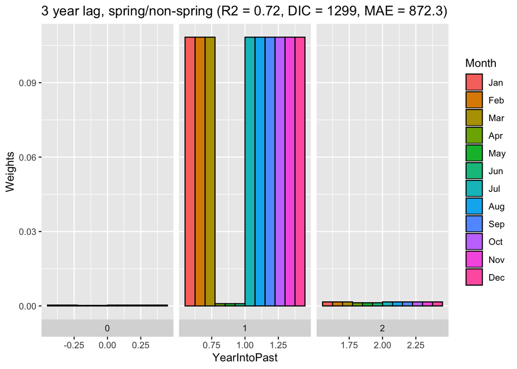

```r
# Assemble the dataframe for spring/non-spring
plotWeights = data.frame("Weights"=as.vector(t(SAM_posterior_3_6_20200325_152051$monthlyWeights$mean)),
                         "YearIntoPast"=rep(0:2,each=12),
                         "Month"=rep(c("Dec","Nov","Oct","Sep", "Aug","Jul",
                                       "Jun", "May","Apr","Mar","Feb","Jan"),3))
# Assign the factors
plotWeights$Month = factor(plotWeights$Month, levels = c("Jan","Feb","Mar","Apr",
                                                         "May","Jun","Jul","Aug",
                                                         "Sep","Oct","Nov","Dec"))
# Create plot ready for grid.assign
plot1 <- ggplot(plotWeights,aes(x=YearIntoPast,y=Weights,fill=Month)) +
      geom_bar(stat="identity", position=position_dodge(), linetype = "solid",size=0.5,color="black") +
      facet_grid(.~YearIntoPast,scales = "free_x",switch = "x", space = "free_y") +
      ggtitle(paste0("3 year lag, spring/non-spring (R2 = ",
                     signif(SAM_posterior_3_6_20200325_152051$R2,2), ", DIC = ",
                     signif(SAM_posterior_3_6_20200325_152051$DIC,4), ", MAE = ",
                     signif(SAM_posterior_3_6_20200325_152051$MAE,4),")"))
grid.arrange(plot1)
```

We have 10 years of Precip and NEE data from FLUXNET - however, because we are looking at a lag of 3 years, we effectively only have 7 years of NEE data. This is an exceptionally short data set.

I may look at the longest data set available, no matter what the ecosystem is.

# Thoughts